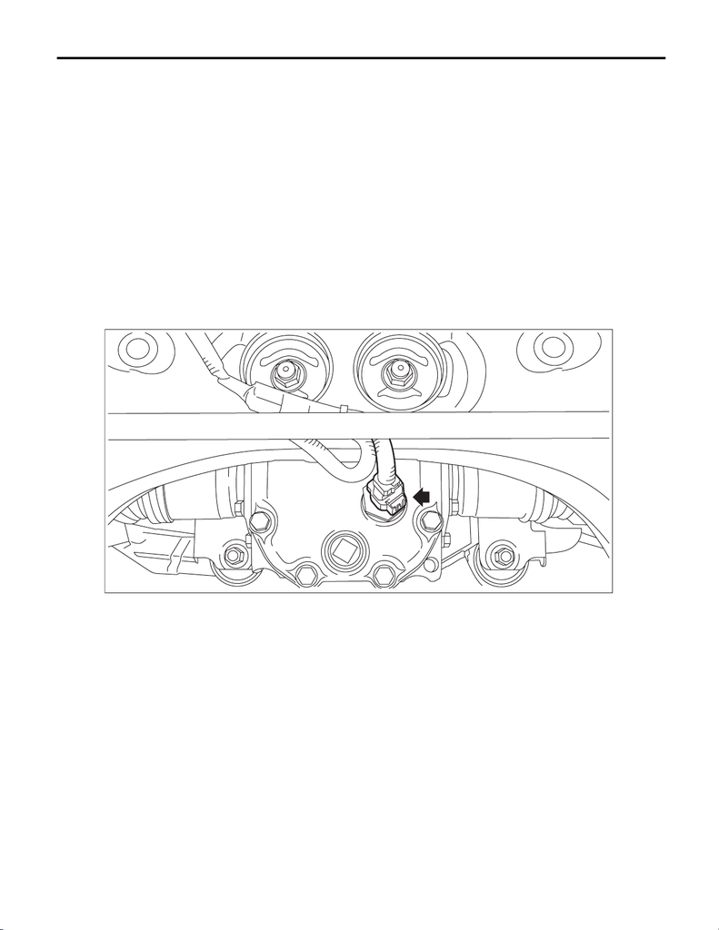

EC(STI)-30

Leak Check Valve Assembly

EMISSION CONTROL (AUX. EMISSION CONTROL DEVICES)

9. Leak Check Valve Assembly

A: REMOVAL

WARNING:

Place “NO OPEN FLAMES” signs near the working area.

CAUTION:

Be careful not to spill fuel.

1) Release the fuel pressure. <Ref. to FU(STI)-64, RELEASING OF FUEL PRESSURE, PROCEDURE, Fu-

el.>

2) Drain fuel. <Ref. to FU(STI)-64, DRAINING FUEL (WITH SUBARU SELECT MONITOR), PROCEDURE,

Fuel.>

3) Disconnect the ground cable from battery.

4) Lift up the vehicle.

5) Remove the rear exhaust pipe. <Ref. to EX(STI)-12, REMOVAL, Rear Exhaust Pipe.>

6) Remove the propeller shaft. <Ref. to DS-12, REMOVAL, Propeller Shaft.>

7) Support the rear differential with the transmission jack.

8) Disconnect the connector from oil temperature sensor.

EC-03445

15WRX_STI_US_EN.book 30 ページ ２０１５年２月１３日 金曜日 午前１１時２０分

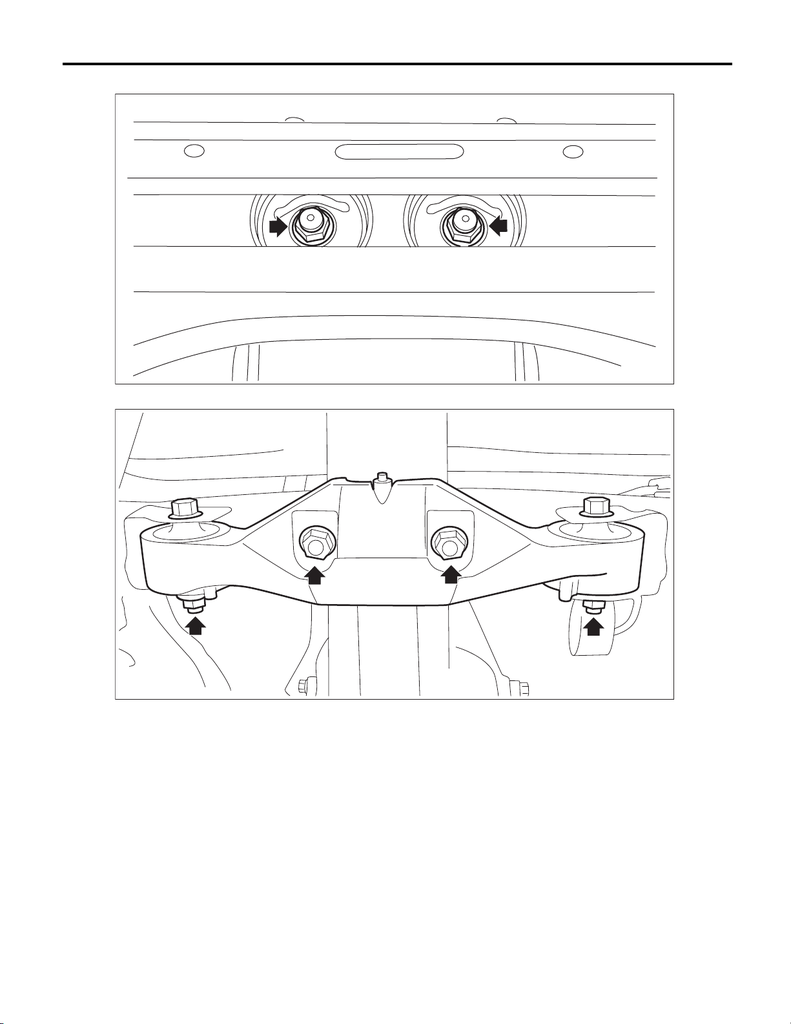

EC(STI)-31

Leak Check Valve Assembly

EMISSION CONTROL (AUX. EMISSION CONTROL DEVICES)

9) Remove the self-locking nuts which hold the rear differential to the rear sub frame assembly.

10) Remove the rear differential member from the rear sub frame assembly and the rear differential.

EC-03420

EC-03453

15WRX_STI_US_EN.book 31 ページ ２０１５年２月１３日 金曜日 午前１１時２０分

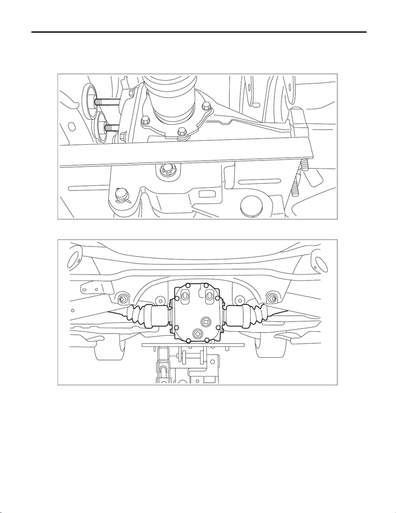

EC(STI)-32

Leak Check Valve Assembly

EMISSION CONTROL (AUX. EMISSION CONTROL DEVICES)

11) Lower the transmission jack gradually until the rear differential is at the position shown in the figure.

NOTE:

• When pulling out the stud bolt from the bushing portion of the rear sub frame assembly, adjust the angle

and location of transmission jack and jack stand.

• Do not lower the rear differential excessively. Doing so may add extra load to the drive shaft or cause the

falling-off of the drive shaft.

EC-03320

EC-03421

15WRX_STI_US_EN.book 32 ページ ２０１５年２月１３日 金曜日 午前１１時２０分

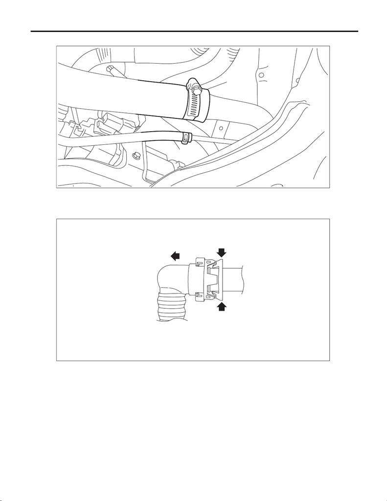

EC(STI)-33

Leak Check Valve Assembly

EMISSION CONTROL (AUX. EMISSION CONTROL DEVICES)

12) Disconnect the fuel filler hose (A) and evaporation hose (B) from the fuel filler pipe assembly.

13) Disconnect the drain tube from the drain pipe.

NOTE:

Disconnect the quick connector as shown in the figure.

FU-08281

(A)

(B)

EC-02999

1

1

2

15WRX_STI_US_EN.book 33 ページ ２０１５年２月１３日 金曜日 午前１１時２０分

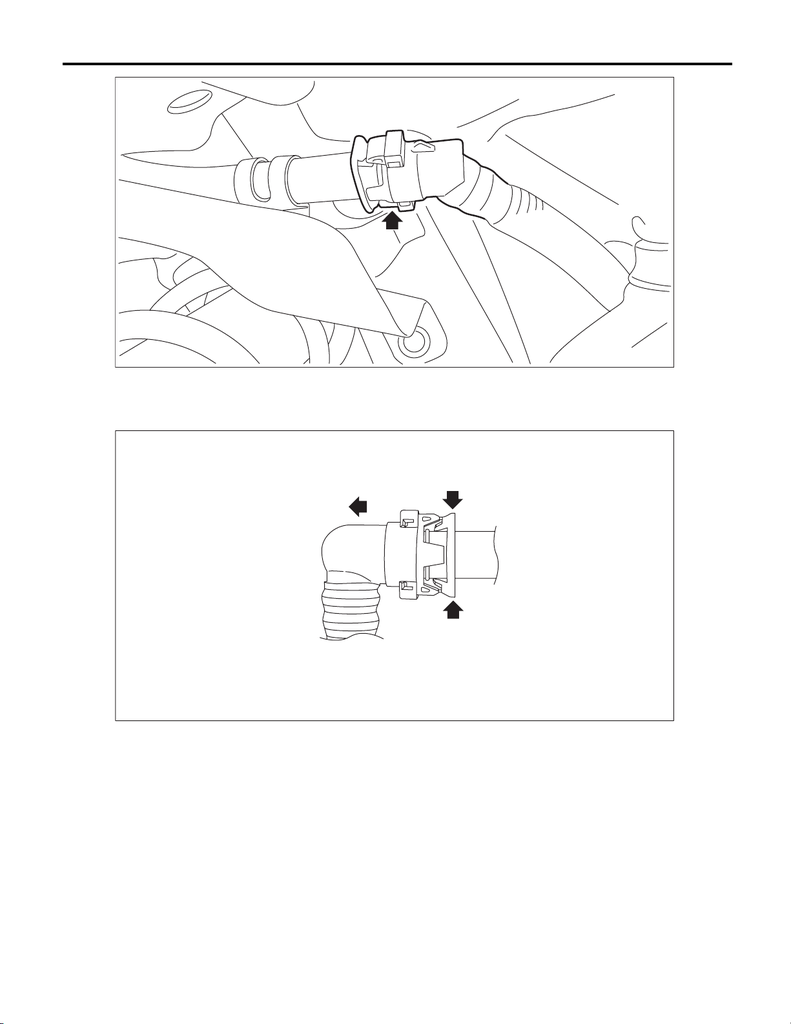

EC(STI)-34

Leak Check Valve Assembly

EMISSION CONTROL (AUX. EMISSION CONTROL DEVICES)

14) Disconnect the drain tube (A) from the canister.

NOTE:

Disconnect the quick connector as shown in the figure.

EC-03430

EC-02999

1

1

2

15WRX_STI_US_EN.book 34 ページ ２０１５年２月１３日 金曜日 午前１１時２０分

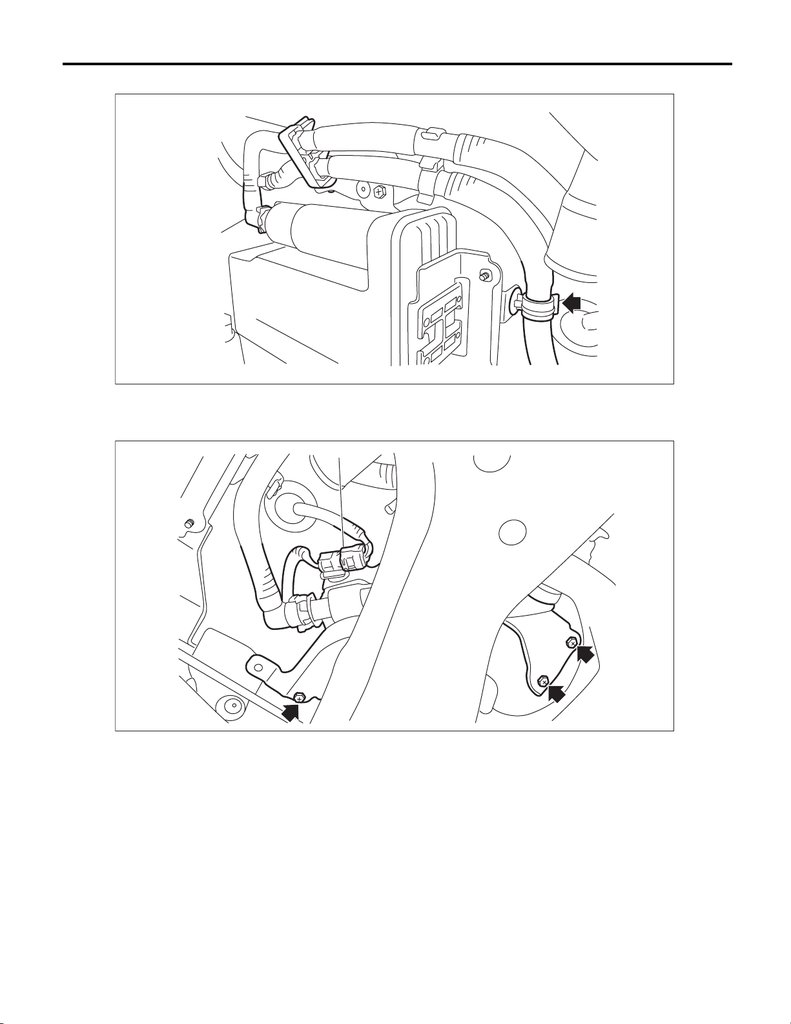

EC(STI)-35

Leak Check Valve Assembly

EMISSION CONTROL (AUX. EMISSION CONTROL DEVICES)

15) Remove the tube clamp (B) from the canister bracket A, and remove the drain tube from the tube clamp.

16) Disconnect the connector (A) from the leak check valve assembly.

17) Remove the bolts which hold the leak check valve assembly and remove the leak check valve assembly

together with drain tube from vehicle.

(A)

(B)

EC-03436

(A)

EC-03429

15WRX_STI_US_EN.book 35 ページ ２０１５年２月１３日 金曜日 午前１１時２０分

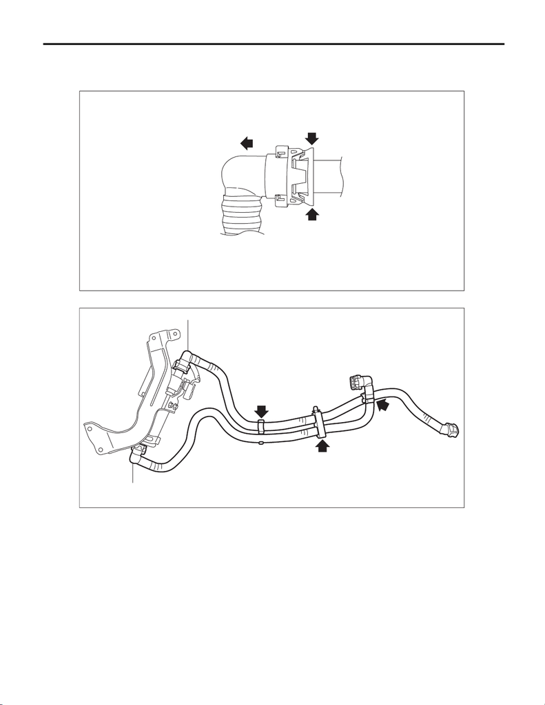

EC(STI)-36

Leak Check Valve Assembly

EMISSION CONTROL (AUX. EMISSION CONTROL DEVICES)

18) Disconnect the drain tube A (A) and drain tube B (B) from the leak check valve assembly.

NOTE:

Disconnect the quick connector as shown in the figure.

19) Remove the tube clamp from the drain tube A (A) and drain tube B (B).

EC-02999

1

1

2

(A)

(B)

EC-03431

15WRX_STI_US_EN.book 36 ページ ２０１５年２月１３日 金曜日 午前１１時２０分

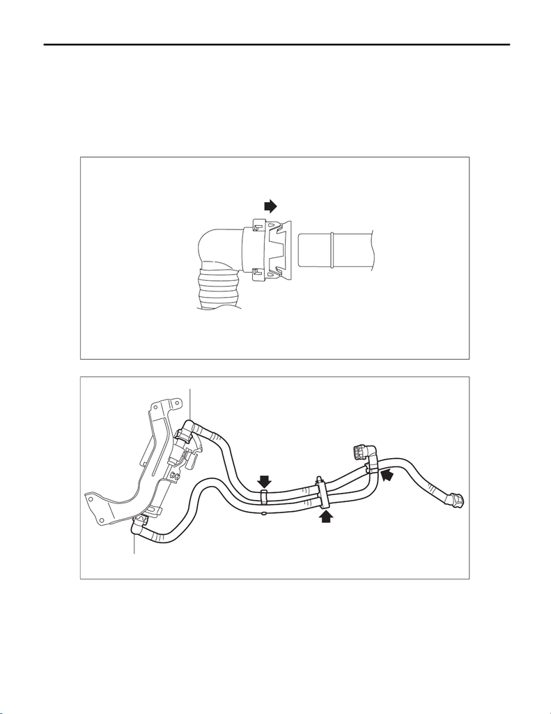

EC(STI)-37

Leak Check Valve Assembly

EMISSION CONTROL (AUX. EMISSION CONTROL DEVICES)

B: INSTALLATION

1) Connect the drain tube A (A) and drain tube B (B) to the leak check valve assembly.

CAUTION:

• Check that there is no damage or dust on the quick connector. If necessary, clean the seal surface

of the pipe.

• Make sure that the quick connector is securely connected.

NOTE:

Connect the quick connector as shown in the figure.

2) Install the tube clamp to the drain tube A (A) and drain tube B (B).

3) Set the leak check valve assembly together with drain tube to the vehicle and install the bolt which holds

the leak check valve assembly.

Tightening torque:

7.5 N·m (0.8 kgf-m, 5.5 ft-lb)

EC-03000

(A)

(B)

EC-03431

15WRX_STI_US_EN.book 37 ページ ２０１５年２月１３日 金曜日 午前１１時２０分

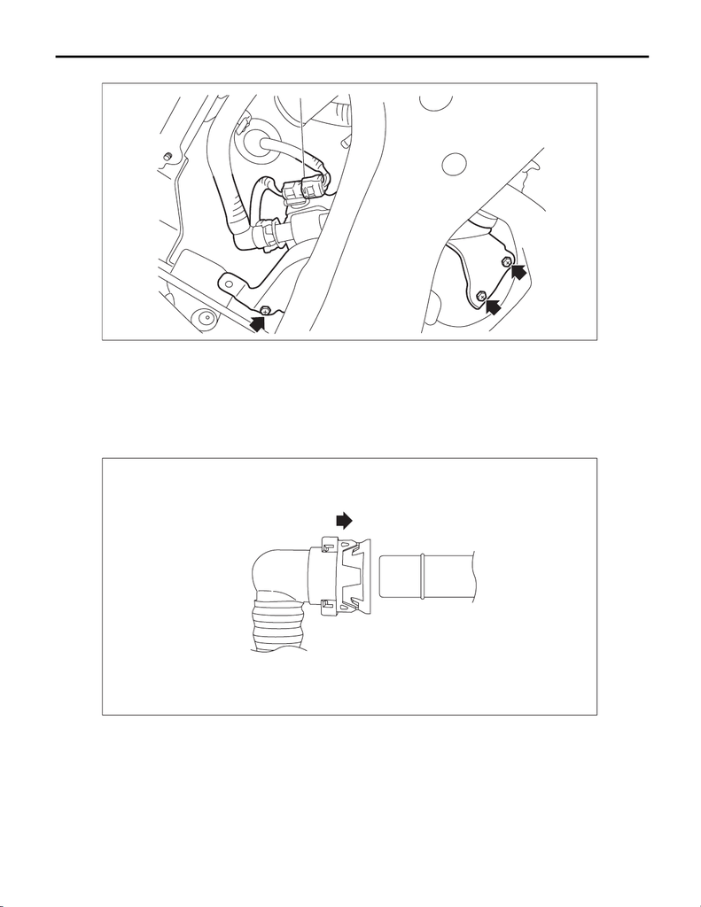

EC(STI)-38

Leak Check Valve Assembly

EMISSION CONTROL (AUX. EMISSION CONTROL DEVICES)

4) Connect the connector (A) to the leak check valve assembly.

5) Connect the drain tube (A) to the canister.

CAUTION:

• Check that there is no damage or dust on the quick connector. If necessary, clean the seal surface

of the pipe.

• Make sure that the quick connector is securely connected.

NOTE:

Connect the quick connector as shown in the figure.

(A)

EC-03429

EC-03000

15WRX_STI_US_EN.book 38 ページ ２０１５年２月１３日 金曜日 午前１１時２０分

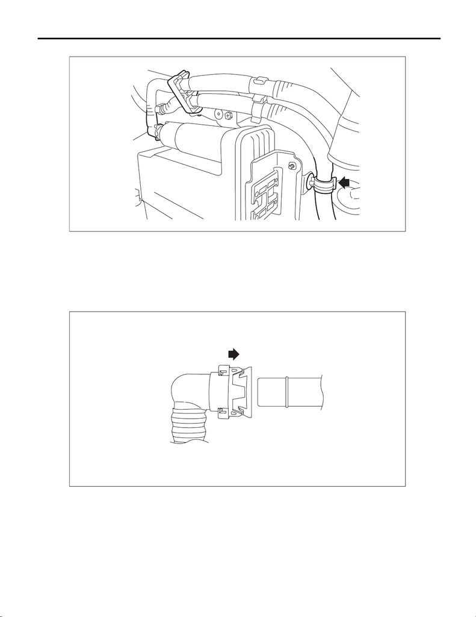

EC(STI)-39

Leak Check Valve Assembly

EMISSION CONTROL (AUX. EMISSION CONTROL DEVICES)

6) Install the tube clamp (B) to the canister bracket A, and install the drain tube to the tube clamp.

7) Connect the drain tube to the drain pipe.

CAUTION:

• Check that there is no damage or dust on the quick connector. If necessary, clean the seal surface

of the pipe.

• Make sure that the quick connector is securely connected.

NOTE:

Connect the quick connector as shown in the figure.

(A)

(B)

EC-03436

EC-03000

15WRX_STI_US_EN.book 39 ページ ２０１５年２月１３日 金曜日 午前１１時２０分

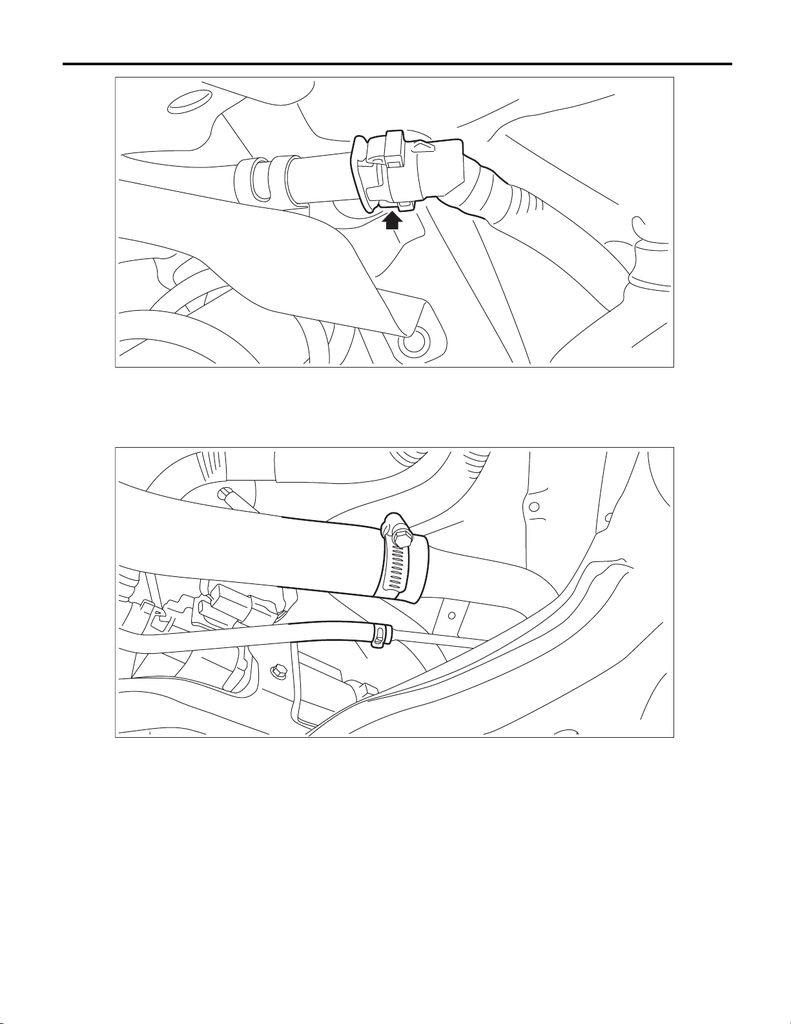

EC(STI)-40

Leak Check Valve Assembly

EMISSION CONTROL (AUX. EMISSION CONTROL DEVICES)

8) Securely insert the fuel filler hose (A) and evaporation hose (B) until the hose end contacts the spool, then

attach the clamp and clip as shown in the figure.

Tightening torque:

2.5 N·m (0.3 kgf-m, 1.8 ft-lb)

EC-03430

FU-08281

(A)

(B)

15WRX_STI_US_EN.book 40 ページ ２０１５年２月１３日 金曜日 午前１１時２０分

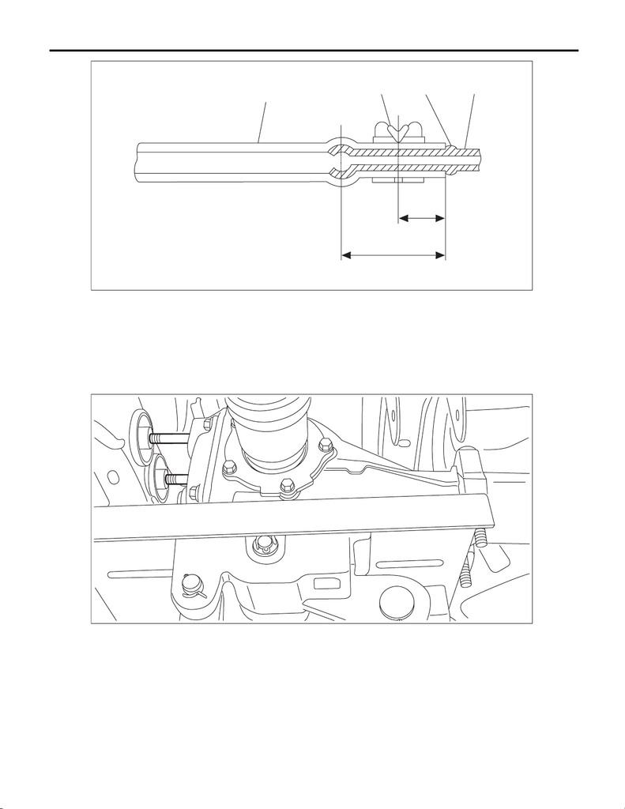

EC(STI)-41

Leak Check Valve Assembly

EMISSION CONTROL (AUX. EMISSION CONTROL DEVICES)

9) Lift up the transmission jack gradually, and set the rear differential to the rear sub frame assembly.

NOTE:

When inserting the stud bolt into the bushing portion of the rear sub frame assembly, adjust the angle and lo-

cation of transmission jack and jack stand.

(1) Hose (3) Spool (4) Pipe

(2) Clamp and clip

L

L/2

(1)

(2)

(3)

(4)

FU-06185

EC-03320

15WRX_STI_US_EN.book 41 ページ ２０１５年２月１３日 金曜日 午前１１時２０分

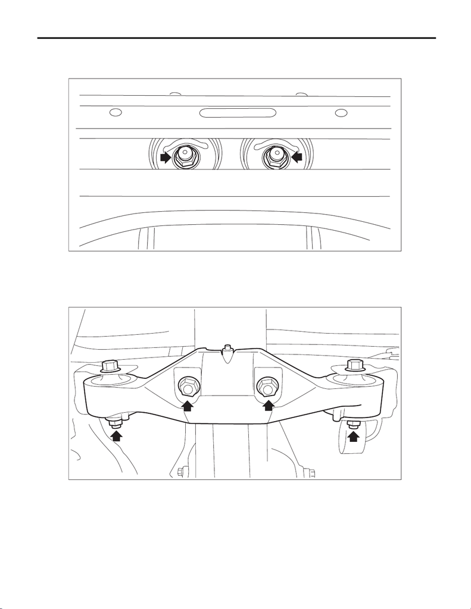

EC(STI)-42

Leak Check Valve Assembly

EMISSION CONTROL (AUX. EMISSION CONTROL DEVICES)

10) Temporarily tighten the self-locking nuts which hold the rear differential to the rear sub frame assembly.

NOTE:

Use a new self-locking nut.

11) Set the rear differential member to the rear sub frame assembly and rear differential, and temporarily

tighten the self-lock nuts which secure the rear differential member to the rear sub frame assembly and rear

differential.

NOTE:

Use a new self-locking nut.

12) Remove the transmission jack from the rear differential.

EC-03420

EC-03453

15WRX_STI_US_EN.book 42 ページ ２０１５年２月１３日 金曜日 午前１１時２０分

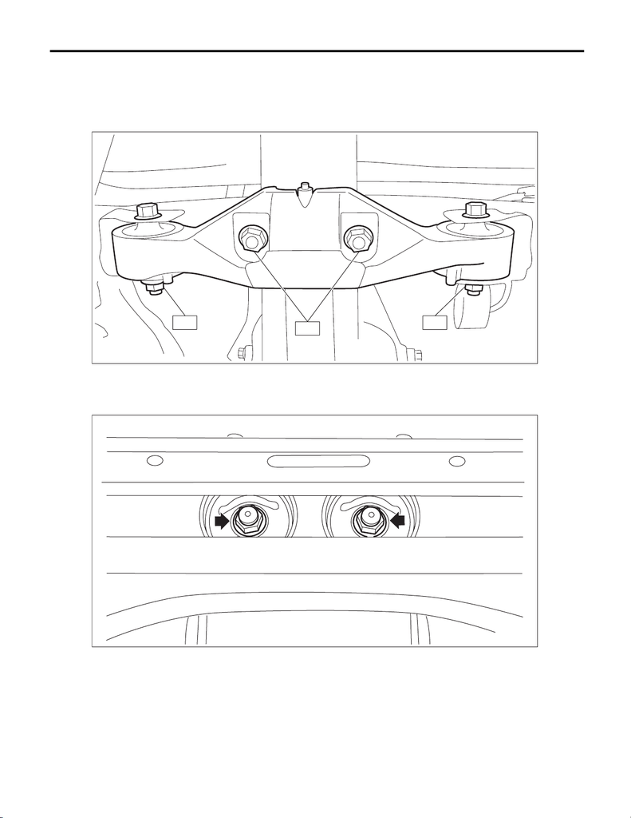

EC(STI)-43

Leak Check Valve Assembly

EMISSION CONTROL (AUX. EMISSION CONTROL DEVICES)

13) Tighten the self-locking nuts which secure the rear differential member to the rear sub frame assembly

and rear differential.

Tightening torque:

T1: 50 N·m (5.1 kgf-m, 36.9 ft-lb)

T2: 110 N·m (11.2 kgf-m, 81.1 ft-lb)

14) Tighten the self-locking nuts which secure the rear differential to the rear sub frame assembly.

Tightening torque:

70 N·m (7.1 kgf-m, 51.6 ft-lb)

EC-03444

T1

T2

T2

EC-03420

15WRX_STI_US_EN.book 43 ページ ２０１５年２月１３日 金曜日 午前１１時２０分

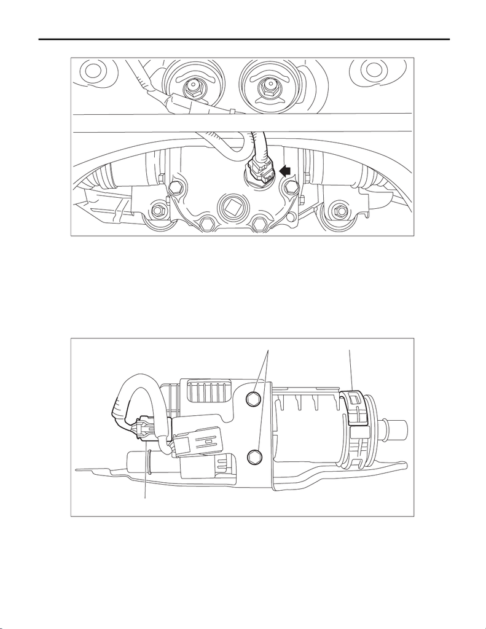

EC(STI)-44

Leak Check Valve Assembly

EMISSION CONTROL (AUX. EMISSION CONTROL DEVICES)

15) Connect the connector to the oil temperature sensor.

16) Install the propeller shaft. <Ref. to DS-14, INSTALLATION, Propeller Shaft.>

17) Install the rear exhaust pipe. <Ref. to EX(STI)-12, INSTALLATION, Rear Exhaust Pipe.>

18) Lower the vehicle.

19) Connect the ground terminal to the battery.

C: DISASSEMBLY

1) Disconnect the connector (A) from the leak check valve assembly.

2) Remove the bolt (B) securing the leak check valve assembly to the leak check valve bracket.

3) Remove the clamp B (C) which secures the leak check valve assembly, and remove the leak check valve

assembly.

4) Remove the harness (A) from the leak check valve bracket.

EC-03445

(C)(B)

(A)

EC-03432

15WRX_STI_US_EN.book 44 ページ ２０１５年２月１３日 金曜日 午前１１時２０分

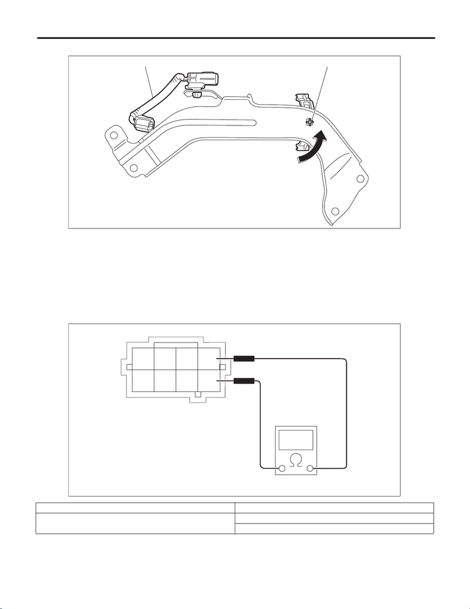

EC(STI)-45

Leak Check Valve Assembly

EMISSION CONTROL (AUX. EMISSION CONTROL DEVICES)

5) Rotate the clamp A (B) in the direction of the arrow and remove it from the leak check valve bracket.

D: ASSEMBLY

Assemble in the reverse order of disassembly.

Tightening torque:

5.4 N·m (0.6 kgf-m, 4.0 ft-lb)

E: INSPECTION

1. CHECK SWITCHING VALVE

1) Check the resistance between switching valve terminals.

Terminal No. Standard

1 and 5

27

+3

–2

Ω (when 20°C (68°F))

31±4 Ω (60°C (140°F))

(A)

(B)

EC-03433

4

3

1

8 7 6 5

2

EC-02813

15WRX_STI_US_EN.book 45 ページ ２０１５年２月１３日 金曜日 午前１１時２０分

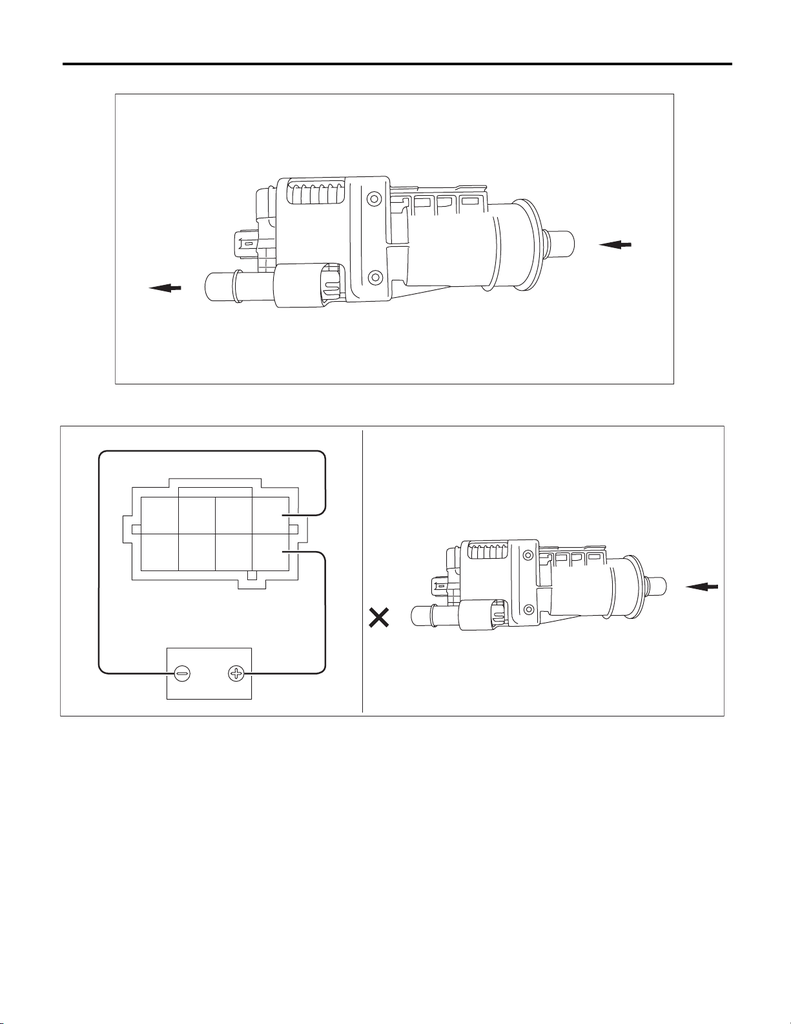

EC(STI)-46

Leak Check Valve Assembly

EMISSION CONTROL (AUX. EMISSION CONTROL DEVICES)

2) Check that air is discharged from (B) when air is blown into (A).

3) Connect the battery positive terminal to the terminal No. 5 and the battery negative terminal to the terminal

No. 1. Check that air does not come out from (B) when air is blown into (A).

EC-03413

(A)

(B)

EC-03393

4

3

1

8 7 6 5

2

(A)

(B)

15WRX_STI_US_EN.book 46 ページ ２０１５年２月１３日 金曜日 午前１１時２０分

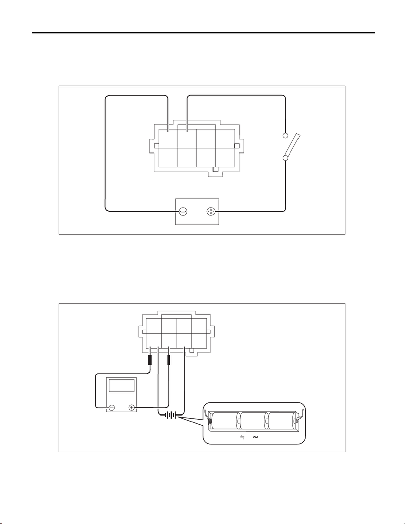

EC(STI)-47

Leak Check Valve Assembly

EMISSION CONTROL (AUX. EMISSION CONTROL DEVICES)

2. CHECK VACUUM PUMP

1) Connect the battery positive terminal to terminal No. 3 and the battery ground terminal to terminal No. 4,

and inspect the vacuum pump operation.

CAUTION:

Do not operate the vacuum pump for 5 minutes or more.

3. CHECK PRESSURE SENSOR

1) Connect dry-cell battery positive terminal to terminal No. 6 and dry-cell battery ground terminal to terminal

No. 8, circuit tester positive terminal to terminal No. 7 and the circuit tester negative terminal to terminal No. 8.

NOTE:

• Use new dry-cell batteries.

• Using circuit tester, check the voltage of a single dry-cell battery is 1.6 V or more. And also check the volt-

age of three batteries in series is between 4.8 V and 5.2 V.

4

3

1

8 7 6 5

2

EC-02804

EC-02805

1.5V

1.5V

1.5V

4.8 5.2V

4

3

1

8 7 6 5

2

V

15WRX_STI_US_EN.book 47 ページ ２０１５年２月１３日 金曜日 午前１１時２０分

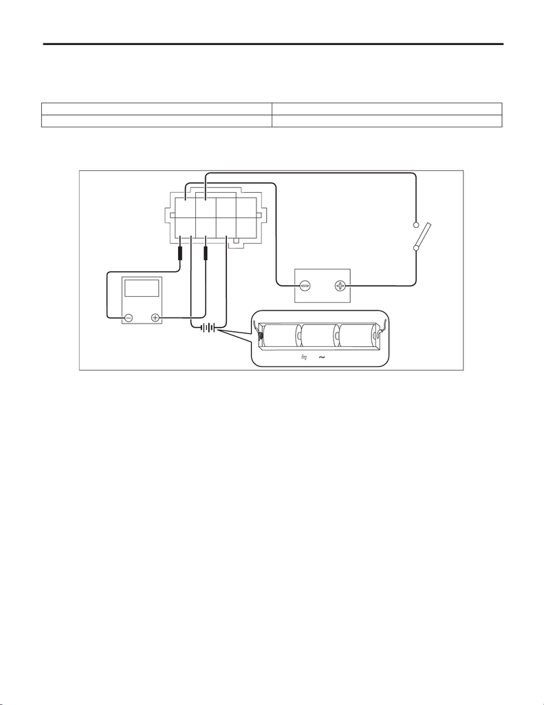

EC(STI)-48

Leak Check Valve Assembly

EMISSION CONTROL (AUX. EMISSION CONTROL DEVICES)

2) Check the voltage at a normal atmospheric pressure.

NOTE:

The atmospheric pressure at higher altitude is lower than normal. Therefore, the voltage is lower than the

standard value.

3) Connect the battery positive terminal to terminal No. 3 and the battery ground terminal to terminal No. 4,

and check that there is a voltage drop from the voltage measured in step 2) when the vacuum pump is op-

erated.

4. OTHER INSPECTIONS

1) Check that the leak check valve assembly and leak check valve bracket have no deformation, cracks or

other damages.

2) Check that the tube has no cracks, damage or loose part.

Terminal No. Standard

7 (+) and 8 (–) Approx. 3.5 V (when 25°C (77°F))

EC-02810

1.5V

1.5V

1.5V

4.8 5.2V

4

3

1

8 7 6 5

2

V

15WRX_STI_US_EN.book 48 ページ ２０１５年２月１３日 金曜日 午前１１時２０分